# Ch04 単語間の関係:nグラムと相関

いままでは単位としての単語が センテンスや文書との間に持つ関係について考えてきた. ここでは「ある単語の後に出てきやすい単語」など 同じ文書の中でも共起することが多い単語の間の 関係からも多くの面白い分析が出来ることを示す.

- tokenにはngramsを使う
- ggraph, widyrで可視化を行う

# ライブラリー

```r
config <- yaml::read_yaml("config.yaml")
ap <- available.packages()
for (p in config$LIBS$CRAN) {
  if (! p %in% ap) {
    install.packages(p)
  }
  library(p, character.only = TRUE)
}
```

# nグラムによるトークン化

単語Xの後に単語Yが続く頻度を調べれば, それらの間の関係を示すモデルを作ることができる. これには`unnest_toknes`でnを指定した上でngramsを トークンに指定すれば良い.

> n=2は2つの連続する単語を指しており, バイグラムと呼ばれて よく分析に用いられる.

```r
austen_bigrams <-
  austen_books() %>%
  unnest_tokens(bigram, text, token = "ngrams", n = 2)

austen_bigrams %>% top_n (20)
```

| book | bigram |
| --- | --- |
| Sense & Sensibility | zealously active |
| Sense & Sensibility | zeal in |
| Sense & Sensibility | zealous attention |
| Sense & Sensibility | zeal with |
| Sense & Sensibility | zealous affection |
| Mansfield Park | zealous in |
| Mansfield Park | zeal could |
| Mansfield Park | zeal julia |
| Mansfield Park | zeal sir |
| Mansfield Park | zeal and |

[output cut: 12 more lines]

## nグラムの出現頻度とフィルタリング

```r
# countで頻度を算出
austen_bigrams %>%
  count(bigram, sort = TRUE) %>%
  top_n(20)
```

| bigram | n |
| --- | --- |
| of the | 3017 |
| to be | 2787 |
| in the | 2368 |
| it was | 1781 |
| i am | 1545 |
| she had | 1472 |
| of her | 1445 |
| to the | 1387 |
| she was | 1377 |
| had been | 1299 |

[output cut: 10 more lines]

頻出単語はやはりofやtheといった **意味があまりないストップワードが目立つ**ことが わかる.

そこでストップワードを除く整理を行う.

```r
bigrams_separated <-
  austen_bigrams %>%
  separate(bigram, into = c("word1", "word2"), sep = " ")

bigrams_filtered <-
  bigrams_separated %>%
  filter(
    !(word1 %in% stop_words$word |
      word2 %in% stop_words$word
    )
  )

# バイグラムの新しい出現頻度リスト
bigram_counts <-
  bigrams_filtered %>%
  count(word1, word2, sort = TRUE)

bigram_counts %>% top_n(20)
```

| word1 | word2 | n |
| --- | --- | --- |
| sir | thomas | 287 |
| miss | crawford | 215 |
| captain | wentworth | 170 |
| miss | woodhouse | 162 |
| frank | churchill | 132 |
| lady | russell | 118 |
| lady | bertram | 114 |
| sir | walter | 113 |
| miss | fairfax | 109 |
| colonel | brandon | 108 |

[output cut: 10 more lines]

```r
# filterのために分割したバイグラムを
# uniteで戻す
bigram_united <-
  bigrams_filtered %>%
  unite(bigram, word1, word2, sep = " ")

bigram_united %>% top_n(20)
```

| book | bigram |
| --- | --- |
| Sense & Sensibility | zealously active |
| Sense & Sensibility | youthful fancy |
| Sense & Sensibility | youth beauty |
| Sense & Sensibility | youthful infatuation |
| Sense & Sensibility | zealous attention |
| Sense & Sensibility | youth natural |
| Sense & Sensibility | zealous affection |
| Pride & Prejudice | youth health |
| Mansfield Park | zeal julia |
| Mansfield Park | zeal sir |

[output cut: 10 more lines]

トリグラム(n=3)の場合にも同様に処理をする.

```r
austen_books() %>%
  unnest_tokens(
    trigram, text, token = "ngrams", n = 3
  ) %>%
  separate(trigram, str_c("word", 1:3), sep = " ") %>%
  filter(
    !( select(., matches("word")) %>%
       reduce(function(x, y) x | (y %in% stop_words$word), .init = FALSE))
  ) %>%
  count(word1, word2, word3, sort = TRUE)
```

| word1 | word2 | word3 | n |
| --- | --- | --- | --- |
| dear | miss | woodhouse | 23 |
| miss | de | bourgh | 18 |
| lady | catherine | de | 14 |
| catherine | de | bourgh | 13 |
| poor | miss | taylor | 11 |
| sir | walter | elliot | 11 |
| ten | thousand | pounds | 11 |
| dear | sir | thomas | 10 |
| twenty | thousand | pounds | 8 |
| replied | miss | crawford | 7 |

[output cut: 8747 more lines]

## バイグラムの分析

上記のような形式にしておくことで, テキストのお予備分析で役に立つ.

```r
# word2がstreet である場合を調べる
bigrams_filtered %>%
  filter(word2 == "street") %>%
  count(book, word1, sort = TRUE)
```

| book | word1 | n |
| --- | --- | --- |
| Sense & Sensibility | berkeley | 16 |
| Sense & Sensibility | harley | 16 |
| Northanger Abbey | pulteney | 14 |
| Northanger Abbey | milsom | 11 |
| Mansfield Park | wimpole | 10 |
| Pride & Prejudice | gracechurch | 9 |
| Sense & Sensibility | conduit | 6 |
| Sense & Sensibility | bond | 5 |
| Persuasion | milsom | 5 |
| Persuasion | rivers | 4 |

[output cut: 24 more lines]

バイグラムを単語として扱えば, `tf-idf`分析が適用できる.

```r
bigram_tf_idf <-
  bigram_united %>%
  count(book, bigram) %>%
  bind_tf_idf(bigram, book, n) %>%
  arrange(desc(tf_idf))

bigram_tf_idf %>% top_n(20)
```

| book | bigram | n | tf | idf | tf_idf |
| --- | --- | --- | --- | --- | --- |
| Persuasion | captain wentworth | 170 | 0.029855989 | 1.791759 | 0.05349475 |
| Mansfield Park | sir thomas | 287 | 0.028731605 | 1.791759 | 0.05148012 |
| Mansfield Park | miss crawford | 215 | 0.021523676 | 1.791759 | 0.03856525 |
| Persuasion | lady russell | 118 | 0.020723569 | 1.791759 | 0.03713165 |
| Persuasion | sir walter | 113 | 0.019845451 | 1.791759 | 0.03555828 |
| Emma | miss woodhouse | 162 | 0.017009660 | 1.791759 | 0.03047722 |
| Northanger Abbey | miss tilney | 82 | 0.015944002 | 1.791759 | 0.02856782 |
| Sense & Sensibility | colonel brandon | 108 | 0.015020862 | 1.791759 | 0.02691377 |
| Emma | frank churchill | 132 | 0.013859723 | 1.791759 | 0.02483329 |
| Pride & Prejudice | lady catherine | 100 | 0.013804528 | 1.791759 | 0.02473439 |

[output cut: 10 more lines]

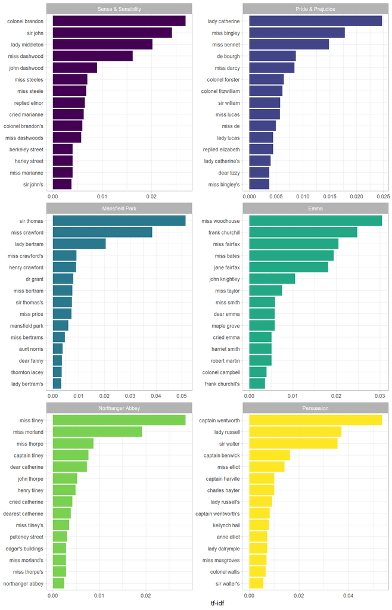

```r
bigram_tf_idf %>%
  arrange(desc(tf_idf)) %>%
  mutate(word = as_factor(bigram) %>% fct_rev()) %>%
  group_by(book) %>%
  top_n(15, tf_idf) %>%
  ungroup()  %>%
  ggplot(aes(word, tf_idf, fill = book)) +
  geom_col(show.legend = FALSE) +
  labs(x = NULL, y = "tf-idf") +
  facet_wrap( ~ book, ncol = 2, scales = "free") +
  coord_flip() +
  theme_light() +
  scale_fill_viridis_d()
```

## センチメント分析のためのバイグラム

ユニグラムのセンチメント分析では, 単語が独立で出現すると考えていたため, 単語のコンテキストが無視されている. 例えば「don’t like」でlikeが出現していても ポジティブな表現であると解釈していた. このような例は下記のように多くみられる.

```r
bigrams_separated %>%
  filter(word1 == "not") %>%
  count(word1, word2, sort = TRUE) %>%
  top_n(20)
```

| word1 | word2 | n |
| --- | --- | --- |
| not | be | 610 |
| not | to | 355 |
| not | have | 327 |
| not | know | 252 |
| not | a | 189 |
| not | think | 176 |
| not | been | 160 |
| not | the | 147 |
| not | at | 129 |
| not | in | 118 |

[output cut: 10 more lines]

例えば次のようにして, notがついた感情を 表す単語で頻出ものが調べられる.

```r
AFINN <- get_sentiments("afinn")
not_words <-
  bigrams_separated %>%
  filter(word1 == "not") %>%
  inner_join(AFINN, by = c(word2 = "word")) %>%
  count(word2, score, sort = TRUE) %>%
  ungroup()

not_words %>% top_n(20)
```

| word2 | score | n |
| --- | --- | --- |
| like | 2 | 99 |
| help | 2 | 82 |
| want | 1 | 45 |
| wish | 1 | 39 |
| allow | 1 | 36 |
| care | 2 | 23 |
| sorry | -1 | 21 |
| leave | -1 | 18 |
| pretend | -1 | 18 |
| worth | 2 | 17 |

[output cut: 11 more lines]

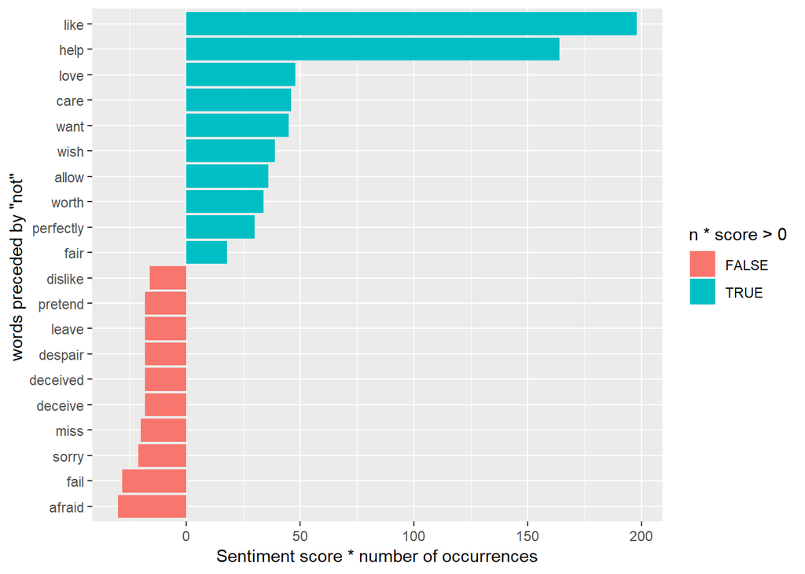

```r
# not で感情表すもののうち間違った方向
not_words %>%
  mutate(contribution = n * score) %>%
  arrange(desc(abs(contribution))) %>%
  head(20) %>%
  mutate(word2 = fct_reorder(word2, contribution)) %>%
  ggplot(aes(word2, n * score, fill = n * score > 0)) +
  geom_col(show.legend = TRUE) +
  xlab("words preceded by \"not\" ") +
  ylab("Sentiment score * number of occurrences") +
  coord_flip()
```

「not」以外の否定語の影響を見てみる.

```r
negation_words <- c("not", "no", "never", "without")

negated_words <-
  bigrams_separated %>%
  filter(word1 %in% negation_words) %>%
  inner_join(AFINN, by = c("word2" = "word")) %>%
  count(word1, word2, score, sort = TRUE) %>%
  ungroup()

negated_words
```

| word1 | word2 | score | n |
| --- | --- | --- | --- |
| no | doubt | -1 | 102 |
| not | like | 2 | 99 |
| not | help | 2 | 82 |
| no | no | -1 | 60 |
| not | want | 1 | 45 |
| not | wish | 1 | 39 |
| not | allow | 1 | 36 |
| not | care | 2 | 23 |
| no | harm | -2 | 22 |
| not | sorry | -1 | 21 |

[output cut: 521 more lines]

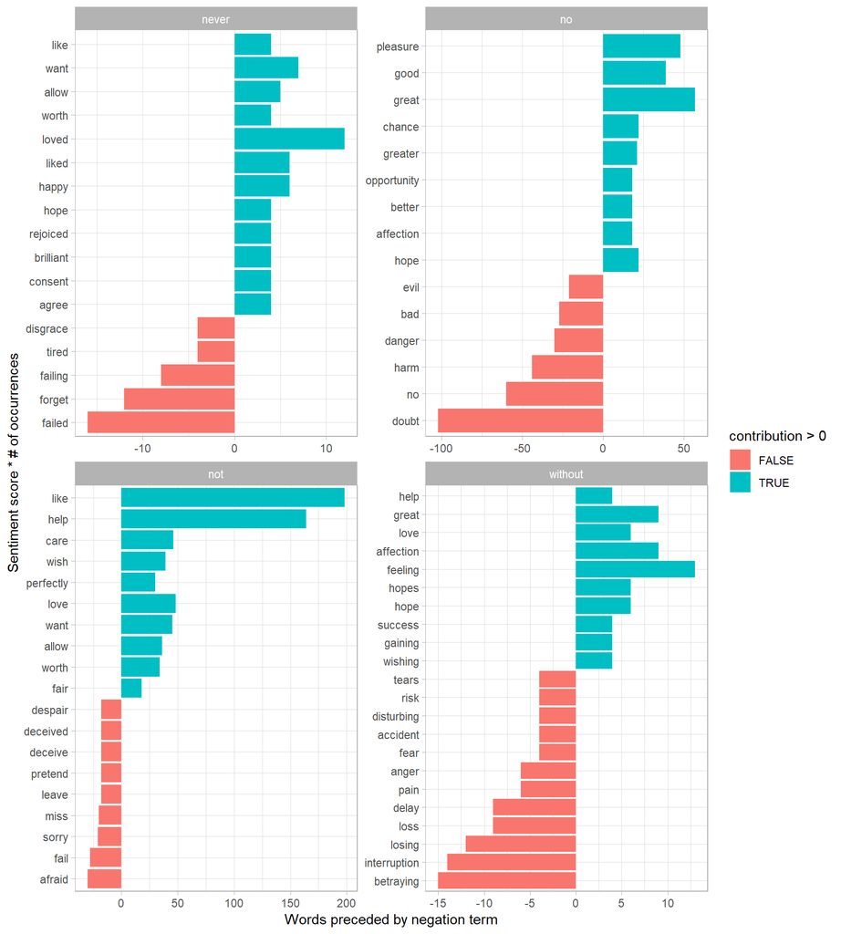

```r
negated_words %>%
  mutate(contribution = n * score) %>%
  arrange(desc(abs(contribution))) %>%
  mutate(word2 = as_factor(word2)) %>%
  group_by(word1) %>%
  top_n(15, abs(contribution)) %>%
  ungroup() %>%
  ggplot(aes(fct_reorder(word2, contribution), contribution, fill = contribution > 0)) +
  geom_col(show.legend = TRUE) +
  xlab("Sentiment score * # of occurrences ") +
  ylab("Words preceded by negation term") +
  coord_flip() +
  facet_wrap( ~ word1, ncol = 2, scale= "free") +
  theme_light()
```

## ggraphを使ったネットワークの可視化

単語間の全ての関係を同時に可視化したい. 次ぎの３つの変数を準備する.

- from
- to
- weight

```r
bigram_graph <-
  bigram_counts %>%
  filter(n > 20) %>%
  graph_from_data_frame()

bigram_graph
```

```
## IGRAPH 6199782 DN-- 91 77 --
## + attr: name (v/c), n (e/n)
## + edges from 6199782 (vertex names):
##  [1] sir     ->thomas     miss    ->crawford   captain ->wentworth
##  [4] miss    ->woodhouse  frank   ->churchill  lady    ->russell
##  [7] lady    ->bertram    sir     ->walter     miss    ->fairfax
## [10] colonel ->brandon    miss    ->bates      lady    ->catherine
## [13] sir     ->john       jane    ->fairfax    miss    ->tilney
## [16] lady    ->middleton  miss    ->bingley    thousand->pounds
## [19] miss    ->dashwood   miss    ->bennet     john    ->knightley
## [22] miss    ->morland    captain ->benwick    dear    ->miss
## + ... omitted several edges
```

作成したigraphオブジェクトをggraphパッケージを 使って可視化をする. なお, **グラフを再現したい場合にはset.seedと使うこと.**

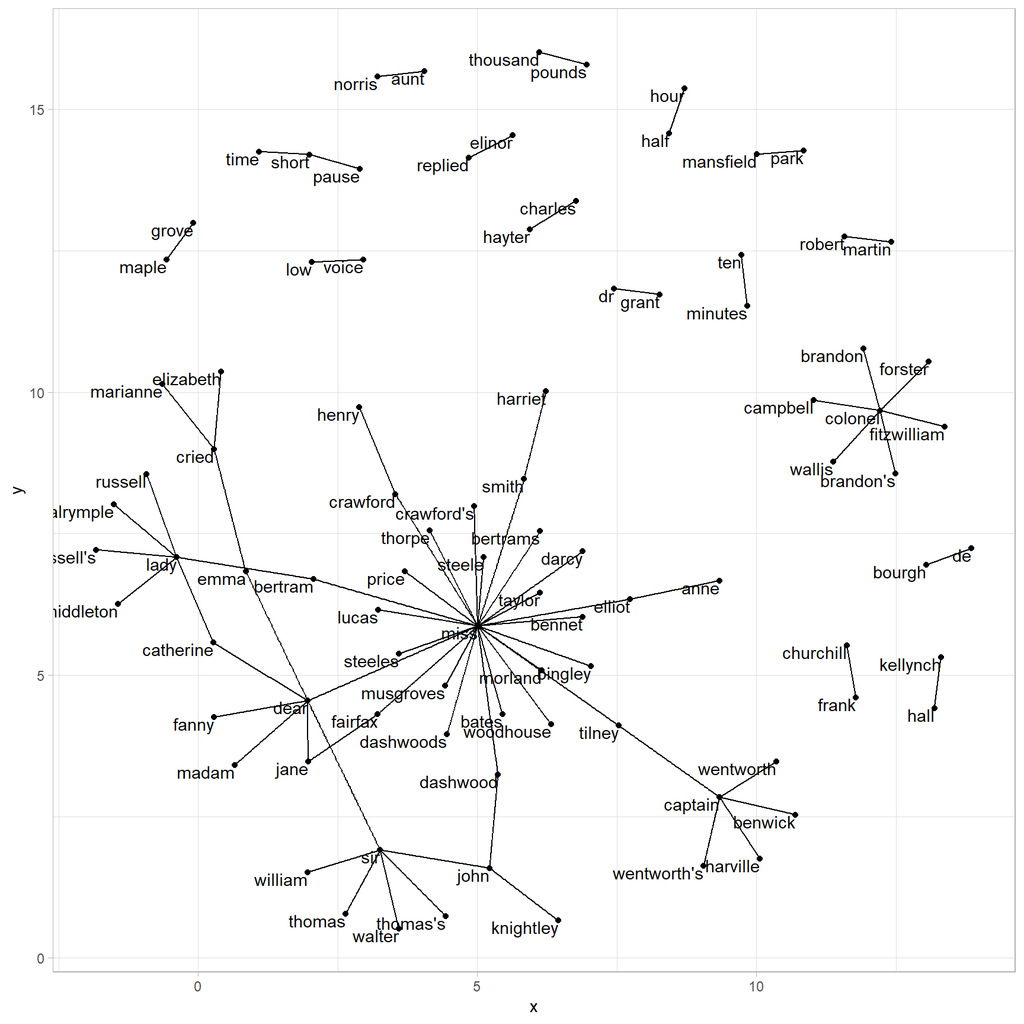

```r
ggraph(bigram_graph, layout = "fr") +
  geom_edge_link() +
  geom_node_point() +
  geom_node_text(
    aes(label = name), vjust = 1, hjust = 1
  ) +
  theme_light()
```

バイグラムの頻度に合わせて, 線の不透明度を 変更する.

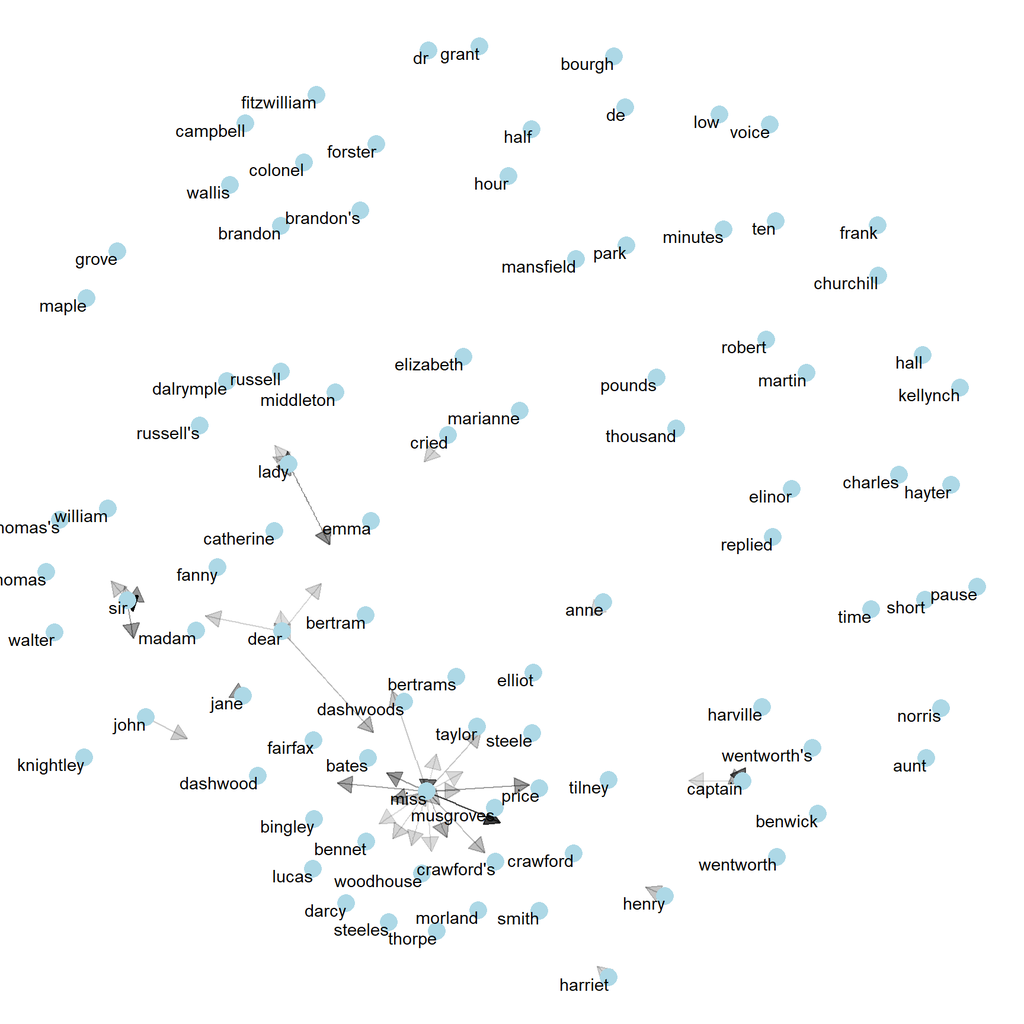

```r
a <- grid::arrow(
  type = "closed", length = unit(.15, "inches"))

ggraph(bigram_graph, layout = "fr") +
  geom_edge_link(
    aes(edge_alpha = n), show.legend = FALSE,
    arrow = a,
    end_cap = circle(.7, 'inches')
  ) +
  geom_node_point(color = "lightblue", size = 5) +
  geom_node_text(aes(label = name), vjust = 1, hjust  =1) +
  theme_void()
```

## ほかのテキストのバイグラムを可視化

ここまでの処理を関数にまとめておく. **ngrams**が処理出来ているので, 教科書よりも汎用的にかけたのでは?

```r
count_ngrams <- function (dataset, n) {
  str_n_words <- str_c("word", seq_len(n))
  sym_n_words <- map(str_n_words, sym)
  dataset %>%
    unnest_tokens(ngram, text, token = "ngrams", n = n) %>%
    separate(ngram, into = str_n_words, sep = " ") %>%
    filter(
      select(., !!! sym_n_words) %>%
      reduce(
        function(x, y) x & !(y %in% stop_words$word), .init = TRUE)) %>%
    count(!!! sym_n_words, sort = TRUE)
}
```

```r
visualize_bigrams <- function(bigrams) {
  arr <- grid::arrow(type = "closed", length = unit(.15, "inches"))

  bigrams %>%
    graph_from_data_frame() %>%
    ggraph(layout = "fr") +
    geom_edge_link(aes(edge_alpha = n), show.legend = FALSE, arrow = arr) +
    geom_node_point(color = "lightblue", size = 5) +
    geom_node_text(aes(label = name), vjust = 1, hjust = 1) +
    theme_void()
}
```

```r
kjv <- gutenberg_download(10)
```

```
## Determining mirror for Project Gutenberg from http://www.gutenberg.org/robot/harvest
```

```
## Using mirror http://aleph.gutenberg.org
```

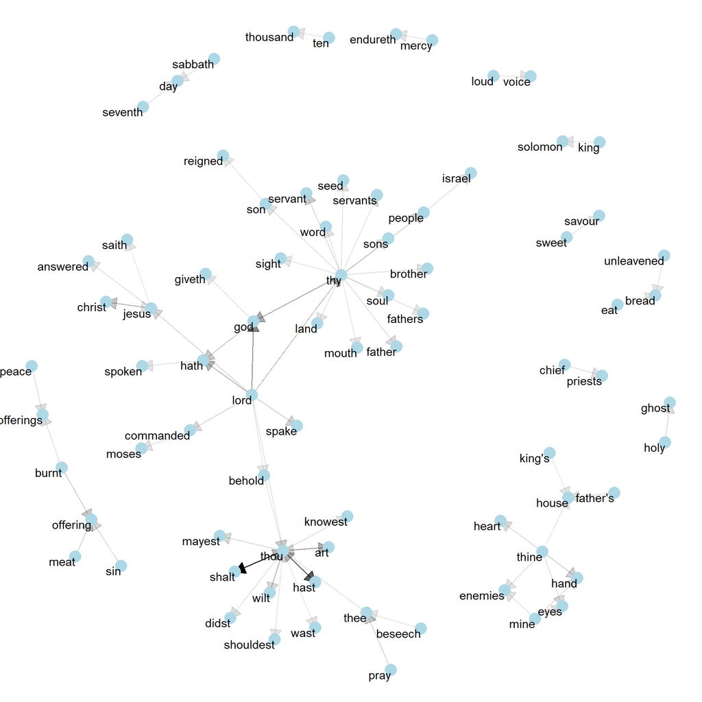

```r
kjv_bigrams <-
  kjv %>%
  count_ngrams(2)

# 数字と出現頻度の低い組み合わせを除去
kjv_bigrams %>%
  filter(
    n > 40,
    ! str_detect(word1, "\\d"),
    ! str_detect(word2, "\\d")) %>%
  visualize_bigrams()
```

# widyrによるバイグラム分析

widyrパッケージでは, 横持ちのデータでの分析を提供してくれる. これにより整理データでは見えにくい, 行単位のデータの 比較がやりやすいくなる. つまり「データをワイド化して処理を実行してから整理形式に戻す」 というパターンを単純化して提供してくれる.

## 節単位の出現頻度と相関

```r
austen_section_words <-
  austen_books() %>%
  filter(book == "Pride & Prejudice") %>%
  mutate(section = row_number() %/% 10) %>%
  filter(section > 0) %>%
  unnest_tokens(word, text) %>%
  filter(! word %in% stop_words$word)

austen_section_words %>% head()
```

| book | section | word |
| --- | --- | --- |
| Pride & Prejudice | 1 | truth |
| Pride & Prejudice | 1 | universally |
| Pride & Prejudice | 1 | acknowledged |
| Pride & Prejudice | 1 | single |
| Pride & Prejudice | 1 | possession |
| Pride & Prejudice | 1 | fortune |

`widyr::pairwise_count`を使うことで, 便利な集計ができる. pairwiseとは, 指定した変数の水準ごとという意味である. これにより, 同じ切ないで共起する2つの単語の出現回数を数えることが できる.

```r
word_pairs <-
  austen_section_words %>%
  pairwise_count(item = word, feature = section, sort = TRUE)
word_pairs %>% top_n(10)
```

| item1 | item2 | n |
| --- | --- | --- |
| darcy | elizabeth | 144 |
| elizabeth | darcy | 144 |
| miss | elizabeth | 110 |
| elizabeth | miss | 110 |
| elizabeth | jane | 106 |
| jane | elizabeth | 106 |
| miss | darcy | 92 |
| darcy | miss | 92 |
| elizabeth | bingley | 91 |
| bingley | elizabeth | 91 |

## ペアごとの相関

[$\phi$係数](https://en.wikipedia.org/wiki/Phi_coefficient)という 値でペアごとの相関を算出する. $n_{01}$は変数1なしで, 変数2が観測された場合である.

```r
word_cors <-
  austen_section_words %>%
  group_by(word) %>%
  filter(n() >= 20) %>%
  pairwise_cor(word, section, sort = TRUE)
word_cors %>% head()
```

| item1 | item2 | correlation |
| --- | --- | --- |
| bourgh | de | 0.9624093 |
| de | bourgh | 0.9624093 |
| pounds | thousand | 0.7692354 |
| thousand | pounds | 0.7692354 |
| catherine | lady | 0.7501901 |
| lady | catherine | 0.7501901 |

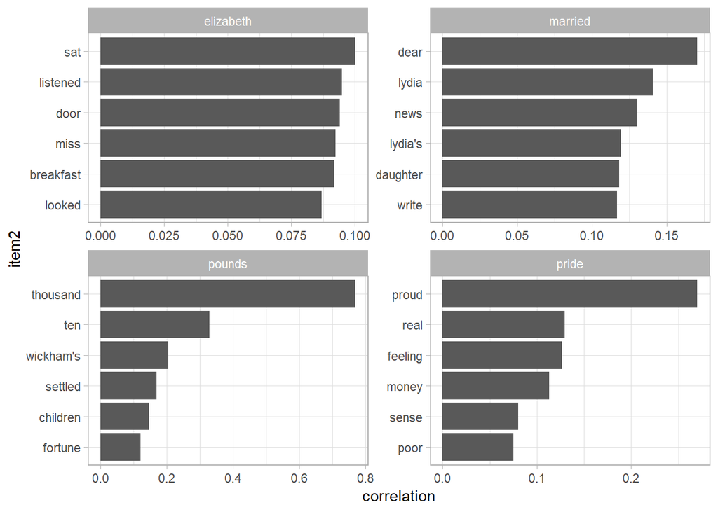

```r
# 可視化
word_cors %>%
  filter(item1 %in% c ("elizabeth", "pounds", "married", "pride")) %>%
  group_by(item1) %>%
  top_n(6) %>%
  ungroup() %>%
  mutate(item2 = reorder(item2, correlation)) %>%
  ggplot(aes(item2, correlation)) +
  geom_col(show.legend = FALSE) +
  facet_wrap( ~ item1, scales = "free") +
  coord_flip() +
  theme_light()
```

ggraphを使えばペア相関についても可視化ができる. ただしこのグラフは→の方向は双方向であることに注意する. バイグラムは有向グラフであった.

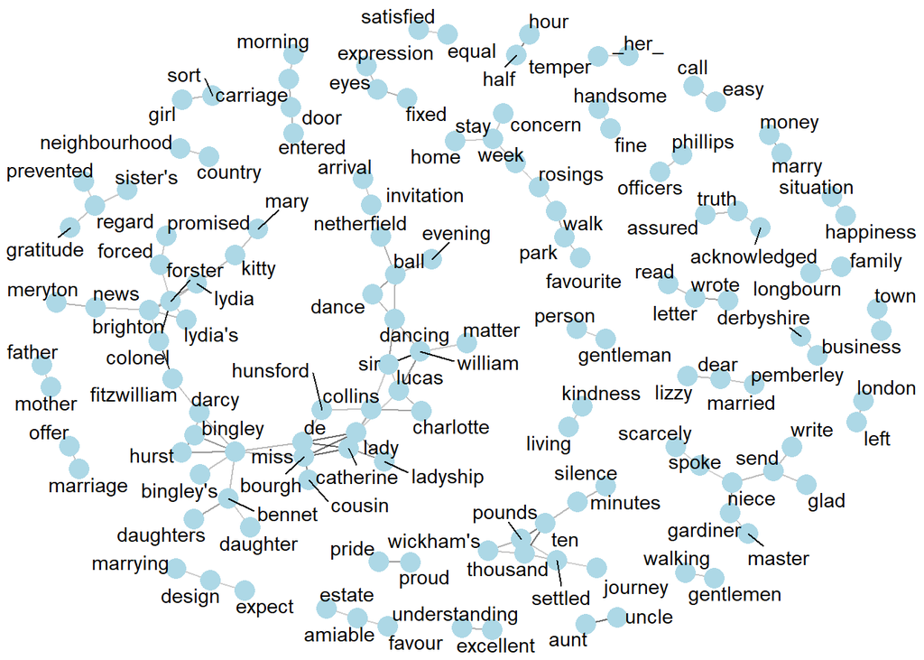

```r
word_cors %>%
  filter(correlation > .15) %>%
  graph_from_data_frame() %>%
  ggraph(layout = "fr") +
  geom_edge_link(aes(edge_alpha = correlation), show.legend = FALSE) +
  geom_node_point(color = "lightblue", size = 5) +
  geom_node_text(aes(label = name), repel = TRUE) +
  theme_void()
```